# Module-9-Advanced-Visualizations-v.1

aaron mamula

5/8/2020

## Introduction and Prerequisites

```r
library(sf)
library(dplyr)
library(data.table)
```

```r
library(ggplot2)
library(RJSONIO)
library(viridis)
```

Here's what's happening in this module:

[The GIS files for geography boundaries can be downloaded here](https://www.census.gov/geographies/mapping-files/time-series/geo/tiger-line-file.2018.html)

I have these saved the CDP boundaries for California to a folder inside the project:

https://github.com/aaronmams/operation-minty-hippo/tree/master/data/shapefiles/tl_2018_06_place

I also grabbed the county boundry shapefile for the US:

https://github.com/aaronmams/operation-minty-hippo/tree/master/data/shapefiles/tl_2019_us_county

## A Test Map

As a first step, read the shapefile with the county boundaries and plot them just to make sure everything looks ok.

```r
county.lines <- st_read('data/shapefiles/tl_2019_us_county/tl_2019_us_county.shp')
str(county.lines)
```

```
## Classes 'sf' and 'data.frame':   3233 obs. of  18 variables:
##  $ STATEFP : chr  "31" "53" "35" "31" ...
##  $ COUNTYFP: chr  "039" "069" "011" "109" ...
##  $ COUNTYNS: chr  "00835841" "01513275" "00933054" "00835876" ...
##  $ GEOID   : chr  "31039" "53069" "35011" "31109" ...
##  $ NAME    : chr  "Cuming" "Wahkiakum" "De Baca" "Lancaster" ...
##  $ NAMELSAD: chr  "Cuming County" "Wahkiakum County" "De Baca County" "Lancaster County" ...
##  $ LSAD    : chr  "06" "06" "06" "06" ...
##  $ CLASSFP : chr  "H1" "H1" "H1" "H1" ...
##  $ MTFCC   : chr  "G4020" "G4020" "G4020" "G4020" ...
##  $ CSAFP   : chr  NA NA NA "339" ...
##  $ CBSAFP  : chr  NA NA NA "30700" ...
##  $ METDIVFP: chr  NA NA NA NA ...
##  $ FUNCSTAT: chr  "A" "A" "A" "A" ...
##  $ ALAND   : num  1.48e+09 6.81e+08 6.02e+09 2.17e+09 1.49e+09 ...
##  $ AWATER  : num  10690952 61582307 29089486 22849484 1718484 ...
##  $ INTPTLAT: chr  "+41.9158651" "+46.2946377" "+34.3592729" "+40.7835474" ...
##  $ INTPTLON: chr  "-096.7885168" "-123.4244583" "-104.3686961" "-096.6886584" ...
##  $ geometry:sfc_MULTIPOLYGON of length 3233; first list element: List of 1
##   ..$ :List of 1
##   .. ..$ : num [1:1320, 1:2] -97 -97 -97 -97 -97 ...
##   ..- attr(*, "class")= chr [1:3] "XY" "MULTIPOLYGON" "sfg"
##  - attr(*, "sf_column")= chr "geometry"
##  - attr(*, "agr")= Factor w/ 3 levels "constant","aggregate",..: NA NA NA NA NA NA NA NA NA NA ...
##   ..- attr(*, "names")= chr [1:17] "STATEFP" "COUNTYFP" "COUNTYNS" "GEOID" ...
```

The thing to note from above is that we have an data frame-looking thing that is object class *sf* with a variety of spatial data type identifiers. The [Simple Features Package](https://r-spatial.github.io/sf/articles/sf1.html) really simplifies working with spatial data because it organizes things in a familiar data-frame looking way.

We can display these county boundaries on a map using the *ggplot()* method.

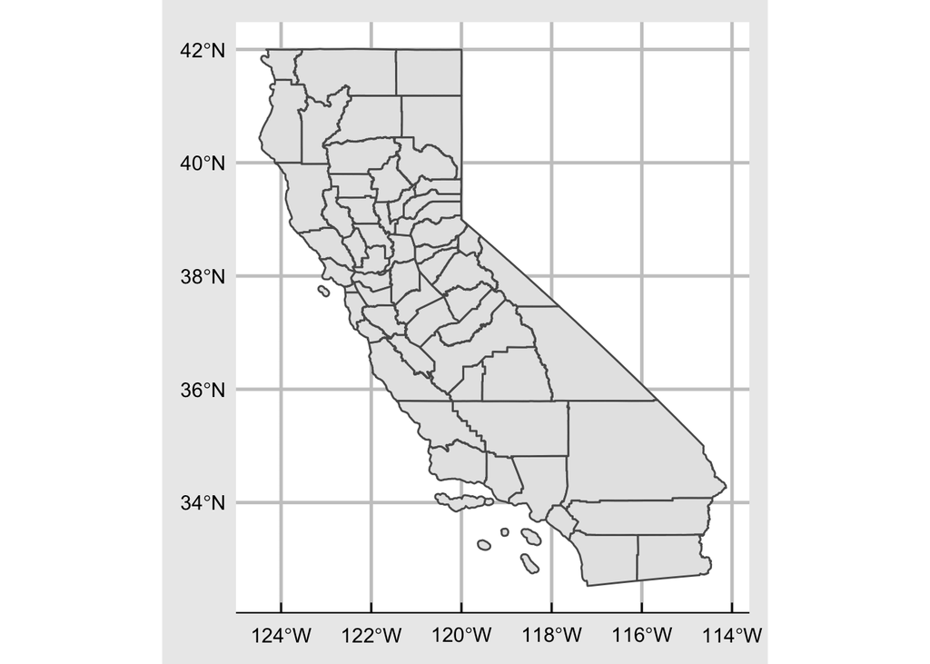

```r
library(ggthemes)
ca.counties <- county.lines %>% filter(STATEFP=='06')
ggplot(ca.counties) + geom_sf() + theme_economist_white()
```

## A Real Map

In the last section I made a base map. This was a map of California county boundaries. Here, I'm going to draw on the skills from Module-7-Data-Import-v.2.2 and pull some data from the 2018 ACS to use with the basemap.

### Get the Educational Attainment Series and Join with Spatial Boundaries

The API url for collecting data at the county level is a little different than the text strings used earlier.

```r
data.series.name <- 'DP02_0064PE'

# my API key
key <- "key=f5a32f694a14b28acf7301f4972eaab8551eafda"
# the base url for Detailed Tables for the 2018 ACS 5-year
base <- "https://api.census.gov/data/2018/acs/acs5/profile?get=NAME,"
# geo parameters
geo <-  "&for=county:*&in=state:06&"

# paste these all together to form the API call for the poverty data series

  endpoint <- paste(base,data.series.name,geo,key,sep="")

  # get json data
  data <- fromJSON(endpoint)

  # parse json object and coerce to data frame
  edu <- tbl_df(data.frame(rbindlist(lapply(data,function(x){
    x<-unlist(x)
    return(data.frame(name=x[1],value=x[2],state=x[3],data_series=data.series.name))
  })
  ))) %>% filter(row_number() > 1)
edu$value <- as.numeric(as.character(edu$value))
```

Next, I need to join these data on educational attainment with the spatial data on county boundaries. One challenge, illustrated below, is that the naming convention is a little different.

County names from the Census ACS data:

```r
head(unique(edu$name))
```

```
## [1] "Lake County, California"          "Mariposa County, California"
## [3] "Yuba County, California"          "Contra Costa County, California"
## [5] "Lassen County, California"        "Santa Barbara County, California"
```

County names from the Census boundaries shapefile:

```r
head(unique(county.lines$NAME[which(county.lines$STATEFP=='06')]))
```

```
## [1] "Sierra"        "Sacramento"    "Santa Barbara" "Calaveras"
## [5] "Ventura"       "Los Angeles"
```

It looks to me like if I just drop the "County, California" part from the ACS name identifiers than the two will be conformable. Let's try:

```r
# I'm changing the column label for the 'name' field in order to be conformable with the county lines
# data. This isn't strictly necessary for a join operation but makes things easier.
edu$NAME <- trimws(gsub("County, California","",edu$name))
head(unique(edu$NAME))
```

```
## [1] "Lake"          "Mariposa"      "Yuba"          "Contra Costa"
## [5] "Lassen"        "Santa Barbara"
```

```r
edu <- edu %>% select(-name)
```

Try joining and see what doesn't work

```r
ca.counties <- county.lines %>% filter(STATEFP=='06') %>% left_join(edu,by=c('NAME'))
ca.counties <- st_as_sf(ca.counties)
```

### Create the Map

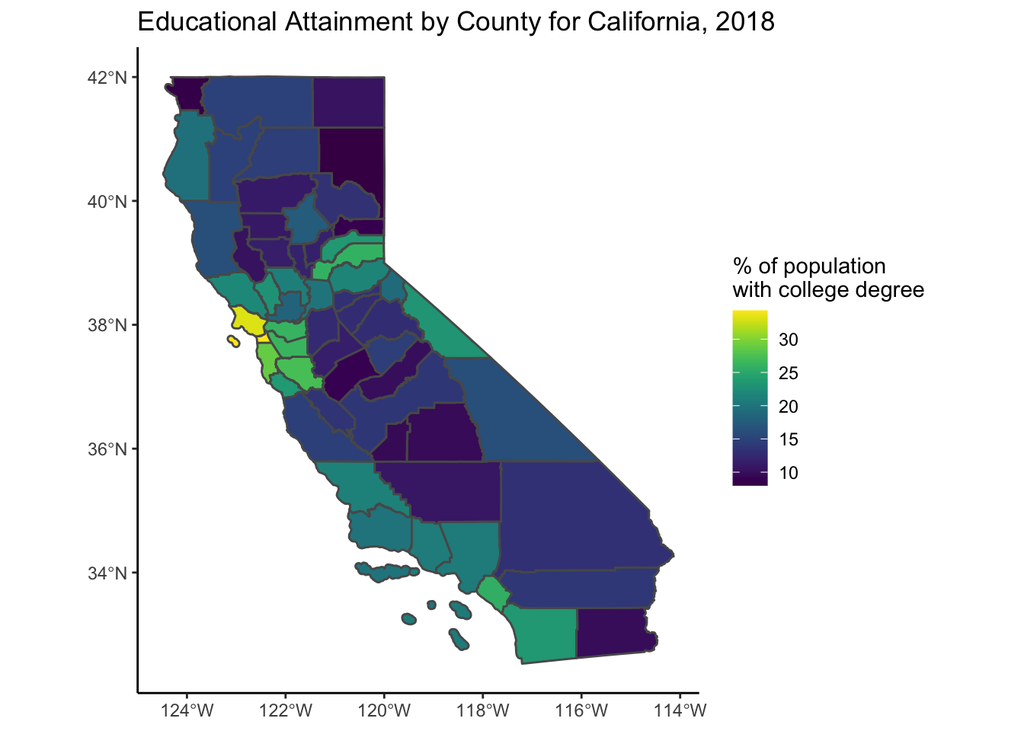

```r
ggplot(ca.counties) + geom_sf(aes(fill=value))  +
 labs(fill="% of population\nwith college degree") +
    scale_fill_viridis() +
  ggtitle("Educational Attainment by County for California, 2018") +
  theme_classic()
```